Innovalab

Introduccion a INLA

# Taller INLA covid

# 1 Analisis Predictivo

El análisis predictivo emplea datos históricos para predecir eventos futuros. Normalmente, los datos históricos se utilizan para crear un modelo que capture diversos patrones temporales. Este modelo predictivo se usa entonces con los datos actuales para predecir lo que acontecera. Existen diversas metodologias para llevar acabo predicciones, en este taller optamos por el enfoque bayesiano para llevar acabo la prediccion.

## 1.1 Enfoque bayesiano : Distribucion predictiva aposteriori

El enfoque bayesiano, en el contexto del analisis predictivo, enfoca su analisis en el calculo de la *distribucion predictiva aposteriori*. Esta distribucion emplea la informacion de los datos asi como la distribucion aposteriori de los parametros de interes . Empleando estos insumos la distribucion predictiva podemos generar datos futuros; es decir, datos faltantes en un determinando horizonte.

$$\begin{align*}
f(y_{pred}|y_{obs}) = \int_{\theta} f(y_{pred},\theta|y_{obs})d\theta =\int_{\theta} f(y_{pred}| \theta y_{obs})f(\theta|y_{obs})d\theta
\end{align*}$$

Actualmente existen diversas metodologias para llevar acabo el calculo numerico de esta distribucion las cuales en **R** corresponden al empleo de un determinado paquete en. Algunos paquetes ampliamente conocidos son los siguientes :

- STAN
- Winbugs
- Jags

Relativamente hace no mucho tiempo la metolodogia de la **Aproximación anidada integrada de Laplace** o **INLA**(por sus siglas en ingles) ha cobrado importancia por su relativa eficiencia para estimar modelos complejos.

## 1.2 Prediccion como datos faltantes

El analisis de prediccion como en la practica puede ser entendida como predecir datos desconocidos en un determinado horizonte. En ese sentido estos datos a futuro pueden ser interpretados como datos faltantes o missings values, los cuales son el objeto de la predicción.

| Año | Semana | Numero de muertes |
| --- | --- | --- |
| 2019 | 1 | 0 |
| 2019 | 2 | 1 |
| 2019 | 3 | 4 |
| 2020 | 1 | 0 |
| 2020 | 2 | 1 |
| 2020 | 3 | 4 |
| 2021 | 1 | NA |
| 2021 | 2 | NA |
| 2021 | 3 | NA |

Para llevar acabo predicciones empleando **INLA**, una aproximacion es justamente la anterior. Una vez dispuestos los datos como en la tabla anterior, basta con ajustar un modelo tipico en INLA, ya que **INLA** internamente calculara la *distribucion predictiva aposteriori* .

# 2 Analisis Descriptivo

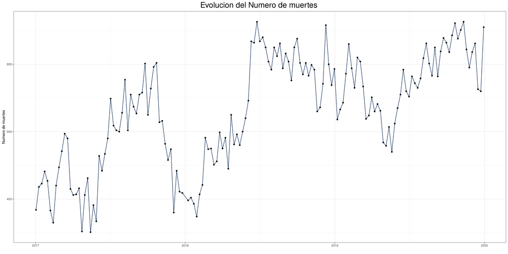

```r
library(tidyverse)
library(INLA)
library(yardstick)
library(gt)
library(innovar)
library(spdep)
library(reshape2)

db       <- readRDS("db_excess_proc.rds")
db.lima <- db %>%
            filter(prov=="LIMA")


db.lima %>%
ggplot()+
geom_line(aes(x=date,y=n),color="#011f4b")+
geom_point(aes(x=date,y=n),color="black")+
ylab("Numero de muertes")+
xlab("")+
ggtitle("Evolucion del Numero de muertes ")+
theme_bw()+
theme(plot.title = element_text(hjust = 0.5,size = "22"),
      strip.background =element_rect(fill="#011f4b"),
      strip.text = element_text(color = "white",face = "bold",size = "5pts"))
```

## 2.1 Modelamiento con INLA

Para llevar acabo el ajuste de modelos empleamos la funcion `inla()`, la cual tiene diversos parametros, algunos de los mas importantes son :

- `data` : Un objeto tipicamente de la clase `data.frame` el cual representa los datos para ajustar el modelo
- `formula` : Un objeto de la clase formula que especifica la ecuacion que pretendemos ajustar como por ejemplo `inla(target ~ 1 + x1)`. En la formula podemos especificar efectos lineales (introduciendo el nombre de la `variable`) o no lineales (empleando `f()`).
- `verbose` : Una variable del tipo `boolean`, la cual señala si se desea mostrar en consola el proceso de convergencia

```r
db             <- db                                   %>%
                  mutate(n=ifelse(annus == 2019,NA,n))




db.n           <- db.lima                            %>%
                  mutate(n=ifelse(annus == 2019,NA,n))
```

```r
lima.m.m0 <- inla(n ~ 1 + annus,
                  verbose         = F,
                  data            =  db.n
                  )
```

Los parámetros antes detallados son los esenciales para ejecutar el ajuste de un modelo empleando `INLA`.Sin embargo, algunos parametros extra a tener en consideracion son los siguientes :

- `family`:Objeto de clase `character`.Este parametro es crucial, pues determina la distribucion de la variable objetivo, por defecto se encuentra en `family=Gaussian`.
- `control.compute`:Objeto de la clase `list` permite especificar el calculo de criterios de informacion tales como `aic`,`dic`,`waic`.

```r
lima.m.m1 <- inla(n ~ 1 + annus,
                  verbose           = F,
                  data              =  db.n,
                  control.compute   = list(dic=TRUE, waic=TRUE,cpo=TRUE),
                  control.predictor = list(link = 1),
                  )
```

## 2.2 Prediccion: Enfoque Temporal

En el analisis de prediccion (forecast) tipicamente se emplea datos en el formato de *series de tiempo* para llevarla acabo. Para ello comunmente se asume que las series de tiempo pueden ser descompuestas del siguiente modo :

$$\begin{align*}
y_{t} = S_{t}+T_{t}+e_{t}
\end{align*}$$

donde :  
$S_{t}$ : Estacionalidad  
$T_{t}$ : Tendencia  
$e_{t}$ : Ruido blanco

### 2.2.1 Ajuste y prediccion

Los componentes antes detallados pueden ser modelados en el contexto de INLA empleando distribuciones apriori para cada componente tales como los siguientes:

- linear : `variable`
- AR1 (Proceso autoregresivo de 1er orden) : `f(variable, model = "ar1")`
- RW1 (Paseo aleatorio de 1er orden) : `f(variable, model = "rw1")`
- RW2 (Paseo aleatorio de 2do orden) : `f(variable, model = "rw2")`

Dado el comportamiento que exibe la series que prentedemos modelar, para los componentes :

- Tendencia : Emplearemos una distribucion apriori del tipo autoregresivo(AR1) o linear
- Estacionalidad : Emplearemos una distribucion apriori de tipo de paseo aleatorio de 1er o 2do orden

Tomando en cuenta estas sugerencias procedemos a ajustar un modelo para ello de nueva cuenta empleamos la funcion `inla()` con todos los parametros complementarios que detallamos. Sin embargo, un punto importante a considerar es que el proceso que modelamos es un *proceso de conteo* por lo tanto el supuesto respecto de la distribucion que emplearemos sera el de una binomial negativa `family ="nbinomial"` .

```r
#inla.list.models("likelihood")

# Asumiendo una Distribucion apriori para los años :"ar1"

lima.m.m1 <- inla(n ~ 1 + f(annus,model = "ar1"),
                  control.compute = list(dic=TRUE, waic=TRUE,cpo=TRUE),
                  control.predictor = list(link = 1),
                  verbose         = F,
                  family          = "nbinomial",
                  data            =  db.n
                  )
# Asumiendo una Distribucion apriori para las semanas :"rw1"
lima.m.m2 <- inla(n ~ 1 + f(week,model = "rw1"),
                  control.compute = list(dic=TRUE, waic=TRUE,cpo=TRUE),
                  control.predictor = list( link = 1),
                  verbose         = F,
                  family          = "nbinomial",
                  data            =  db.n
                  )
#
lima.m.m3 <- inla(n ~ 1 + f(annus,model = "ar1") + f(week,model = "rw1"),
                  control.compute = list(dic=TRUE, waic=TRUE,cpo=TRUE),
                  control.predictor = list( link = 1),
                  verbose         = F,
                  family          = "nbinomial",
                  data            =  db.n
                  )
```

Una vez ajustados los modelos podemos recolectar informacion relevante de su ajuste. En este sentido el objeto generado por la función `inla()` es una *lista* que contiene todos los resultados los cuales se corresponden con las opciones(`parametros`) utilizadas durante la ejecucion de `inla()`. En este caso recurrimos a `objetoInla$summary.fitted.values` para recolectar informacion de los valores ajustados.

```r
fit.m.m1 <- lima.m.m1$summary.fitted.values$mean
fit.m.m2 <- lima.m.m2$summary.fitted.values$mean
fit.m.m3 <- lima.m.m3$summary.fitted.values$mean
n.m      <- db.n$n
```

Asimismo procemos a asignar toda la informacion de los valores ajustados de los modelos a un objeto lista. Posteriormente empleamos `melt` para crear una estructura de base de datos adecuada para graficar .Asi como recolectamos informacion de los intervalos de credibilidad de los valores ajustados : `lima.m.m1$summary.fitted.values$0.025quant`, `lima.m.m1$summary.fitted.values$0.975quant`,

```r
datos  <-  list("AR(1)"=fit.m.m1,"RW(1)"=fit.m.m2,"AR(1)RW(1)"=fit.m.m3) %>%
           as.data.frame() %>%
           melt( variable.name = "modelo",
                value.name    = "fit") %>%
           group_by(modelo) %>%
           mutate(actual    = n.m,
                  date      = db.n$date) %>%
           ungroup() %>%
           mutate(min_inter = c(lima.m.m1$summary.fitted.values$`0.025quant`,
                                lima.m.m2$summary.fitted.values$`0.025quant`,
                                lima.m.m3$summary.fitted.values$`0.025quant`),


                  max_inter = c(lima.m.m1$summary.fitted.values$`0.975quant`,
                                lima.m.m2$summary.fitted.values$`0.975quant`,
                                lima.m.m3$summary.fitted.values$`0.975quant`)
           )
```

Posteriormente, graficamos los datos asi como el ajuste de los modelos propuestos con su respectivo intervarlo de credibilidad empleando la funcion `ggplot()` del paquete `ggplot2`

```r
datos %>%
ggplot()                        +
geom_line(aes(x=date,y=actual)) +
geom_line(aes(x=date,y=fit),color="#011f4b")    +
geom_ribbon(aes(x=date,y=fit,ymin=min_inter, ymax=max_inter),
                alpha=0.4,       #transparency
                fill="#011f4b") +
facet_wrap(vars(modelo))        +
theme_bw()+
xlab(" ") +
ylab("Numero de casos")+
geom_vline(xintercept = as.Date("2019-01-07"), linetype="dotted",
                color = "black", size=0.7)+
theme(plot.title = element_text(hjust = 0.5,size = "20pts"),
      strip.background =element_rect(fill="#011f4b"),
      strip.text = element_text(color = "white",face = "bold",size = "5pts"))
```

[figure not shown]

### 2.2.2 Performance

Para el calculo de metricas en la búsqueda de evaluar los modelo propuestos emplearemos el paquete `yardstick` . En particular empleamos la funcion `metric_set` para seleccionar la metricas que deseamos calcular (`mae`,`rmse`,`msd`). Agrupamos los datos por cada modelo para realizar el calculo a ese nivel y finalmente empleamos la funcion `perform.metrics`, para lo cual detallamos los parametros `truth` y `estimate` que recogen los datos verdaderos y ajustados.

```r
perform.metrics <- metric_set(mae, rmse,msd)

tbl.yrd.m <- datos                    %>%
             group_by(modelo)         %>%
             perform.metrics(truth    = n.m,
                           estimate = fit)
```

Finalmente, el objeto resultado de dichas métricas tiene estructura del tipo `larga` por lo que para efectos de reportar estos resultados en una tabla. En primer lugar la estructura `data.frame` es convertida a `ancha` empleando la funcion `pivot_wider` la cual recolecta como nuevos nombres de columnas(`names_from`) los niveles de la variable `.metric` y estas a su vez se rellenan con los valores(`values_from`) de `.estimate`. Finalmente empleamos del paquete `gt` la funcion `gt()` para reportar una tabla personalizada .

```r
tbl.yrd.m                               %>%
pivot_wider(id_cols     = modelo,
            names_from  = .metric,
            values_from = .estimate)    %>%
gt()                                    %>%
tab_header(
    title = md("Métricas de ajuste"),
    subtitle = "Hombres") %>%
data_color(
    columns = vars(rmse,mae,msd),
    colors = scales::col_numeric(
      palette = c(
        "#011f4b","white"),
      domain = NULL)
  )
```

Métricas de ajuste

Hombres

| modelo | mae | rmse | msd |
| --- | --- | --- | --- |
| AR.1. | 64.82772 | 74.38477 | 0.2270898 |
| RW.1. | 45.34475 | 55.74811 | 0.1532117 |
| AR.1.RW.1. | 29.59756 | 37.89493 | 0.1708465 |

## 2.3 Prediccion: Enfoque Espacio-Temporal

El enfoque espacio-temporal, implica complementar el enfoque anterior complejizando el modelo tomando en cuenta la dimesion espacial. Para ello requerimos incluir efectos aleatorios espaciales para controlar por tal dimension de analisis. Cabe mencionar que los modelos espaciales **areales** empleando INLA, requieren necesariamente la creacion de un *grafo(graph)* o una estructura de datos espaciales que capture la disposicion de las areas como una matriz de pesos espaciales.

$$\begin{align*}
y_{t} = S_{t}+T_{t}+\nu_{t}+u_{t}+e_{t}
\end{align*}$$

donde:

$\nu_{t}$ : efectos estructurados

$u_{t}$ : efectos no estructurados

Los 2 nuevos componentes $\nu_{t},u_{t}$ pretenden tomar en consideracion en la prediccion la **correlacion espacial** presente en los datos . Al respecto :

- Los efectos no estructurados corresponden a efectos aleatorios que pretenden controlar caracteristicas no observadas de **cada area** bajo estudio. Para modelarlas podemos emplear `f(area, model = "iid")`
- Los efectos estructurados son efectos aleatorios que toman en cuenta explicitamente la estructura espacial
  - Pueden ser modelados en INLA de diversas maneras:
    - Empleando efectos espaciales besag :`f(area, model = "besag")`
    - Empleando efectos espaciales propios de besag :`f(area, model = "besagproper")`

### 2.3.1 Preprocesamiento

Dado lo expuesto anteriormente, recolectamos la informacion geografica de Peru expresada en un `shapefile`, a nivel provincial . Para lo cual ademas de llamar al shapefile, al agrupar los datos a nivel provincial y emplear la funcion `summarize` buscando condensar los poligonos del shapefile al nivel deseado

```r
data("Peru")

peru.prov<-Peru               %>%
           group_by(reg,prov) %>%
           summarise()
```

Posteriomente, creamos una estructura de vecindad a partir del shapefile , y a su vez de dicha estructura de vecindad creamos la matriz de pesos espaciales

```r
# Creando la estructura de vecinos mas cercanos
peru.adj    <- poly2nb(peru.prov)
# Pesos espaciales
W.peru <- nb2mat(peru.adj, style = "W")
```

Finalmente, realizamos la limpieza de provincias inexistentes; asi como la creacion de un id por cada provincia, para asi poder identificar cada poligono. Esto ultimo representa un requisito extra para ajustar modelos espaciales en `INLA`

```r
db.m.sp<- db                             %>%
          group_by(prov)                             %>%
          filter(!prov %in% c("EXTRANJERO","ARICA")) %>%
          mutate(id.sp=cur_group_id())
```

### 2.3.2 Ajuste y prediccion

Ajustamos el modelo, siguiendo los pasos antes indicados

```r
peru.m.m5   <- inla(n ~ 1 + f(annus,model = "linear") +
                           f(week,model = "rw1")  +
                           f(id.sp, model = "besag", graph = W.peru),
                   data              = db.m.sp,
                   control.compute   = list(dic = TRUE,
                                            waic = TRUE,
                                            cpo = TRUE),
                   control.predictor = list( link = 1)
                  )
```

De nueva cuenta recolectamos la informacion del objeto resultante de emplear `inla()`

```r
db.m.sp.fit    <- db.m.sp                                          %>%
                  ungroup()                                        %>%
                  mutate(fit      =peru.m.m5$summary.fitted.values$mean,
                         min_inter=peru.m.m5$summary.fitted.values$`0.025quant`,
                         max_inter=peru.m.m5$summary.fitted.values$`0.975quant`)


db.lima.m.fit <- db.m.sp.fit %>%
                 filter(prov=="LIMA")





fit.m.m1 <- lima.m.m1$summary.fitted.values$mean
fit.m.m2 <- lima.m.m2$summary.fitted.values$mean
fit.m.m3 <- lima.m.m3$summary.fitted.values$mean
fit.m.m4 <- db.lima.m.fit$fit
min.m.m4 <- db.lima.m.fit$min_inter
max.m.m4 <- db.lima.m.fit$max_inter

n.m      <- db.n$n


datos.m  <-  list("AR(1)"=fit.m.m1,"RW(1)"=fit.m.m2,
                "AR(1)RW(1)"=fit.m.m3,"AR(1)RW(1) with Spatial effects"=fit.m.m4) %>%
           as.data.frame() %>%
           melt( variable.name = "modelo",
                value.name    = "fit") %>%
           group_by(modelo) %>%
           mutate(actual    = n.m,
                  date      = db.n$date) %>%
           ungroup() %>%
           mutate(min_inter = c(lima.m.m1$summary.fitted.values$`0.025quant`,
                                lima.m.m2$summary.fitted.values$`0.025quant`,
                                lima.m.m3$summary.fitted.values$`0.025quant`,
                                min.m.m4),


                  max_inter = c(lima.m.m1$summary.fitted.values$`0.975quant`,
                                lima.m.m2$summary.fitted.values$`0.975quant`,
                                lima.m.m3$summary.fitted.values$`0.975quant`,
                                max.m.m4)
           )
```

y de nueva cuenta graficamos los resultados del modelo para comparar su ajuste respecto de los datos verdaderos .

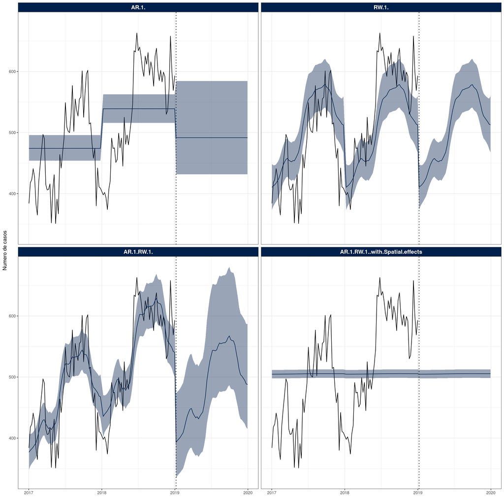

### 2.3.3 Performance

Finalmente, seguimos los mismos pasos que en la sección del enfoque temporal.

```r
perform.metrics <- metric_set(mae, rmse,msd)

tbl.yrd.m <- datos.m                    %>%
             group_by(modelo)         %>%
             perform.metrics(truth    = n.m,
                             estimate = fit)


tbl.yrd.m                               %>%
pivot_wider(id_cols     = modelo,
            names_from  = .metric,
            values_from = .estimate)    %>%
gt()                                    %>%
tab_header(
    title = md("Métricas de ajuste"),
    subtitle = "Hombres") %>%
data_color(
    columns = vars(rmse,mae,msd),
    colors = scales::col_numeric(
      palette = c(
        "#011f4b","white"),
      domain = NULL)
  )
```

Métricas de ajuste

Hombres

| modelo | mae | rmse | msd |
| --- | --- | --- | --- |
| AR.1. | 64.82772 | 74.38477 | 0.2270898 |
| RW.1. | 45.34475 | 55.74811 | 0.1532117 |
| AR.1.RW.1. | 29.59756 | 37.89493 | 0.1708465 |
| AR.1.RW.1..with.Spatial.effects | 71.51461 | 83.42268 | 1.5866506 |